# Analyzing Weather Events from 1950 to 2011

Matiki

April 16, 2018

## Introduction/Synopsis

Extreme weather events can cause harm to public health and economic problems through property damage. In this exploratory analysis we are interested in discovering which events have caused the greatest number of fatalities and injuries in the US between 1950 and 2011, as well as the most amount of damage to property and crops. The data are gathered from the US national Oceanic and Atmospheric Administration’s (NOAA) stomr database.

After looking at how much harm each event type has caused in total, we find that tornadoes have caused the most amount of fatalities and injuries. Floods have the most amount of property damage, while ice storms and river floods have caused the most amount of damage to crops (in billions of dollars).

## Data Processing

Load all the R packages we plan on using into the current R session

```r
# Load required packages into current R session
library(readr)
library(dplyr)
library(ggplot2)
library(tidyr)
library(R.utils)
```

### Download and unzip the raw data file

First we’ll check to see if we already have the unzipped data file in our working directory. If not, we will check to see if we have the zipped file, and download it if necessary, and then unzip the file.

```r
# Check if file exists in working directory
if(!file.exists("storm_data.csv")){

        # Download zipped file if needed
        if(!file.exists("zipped_storm_data.csv.bz2")){
                URL <- "https://d396qusza40orc.cloudfront.net/repdata%2Fdata%2FStormData.csv.bz2"
                download.file(URL,
                              destfile = "zipped_storm_data.csv.bz2")
                rm(URL)
        }

        # Unzip data file
        bunzip2(filename = "zipped_storm_data.csv.bz2",
                destname = "storm_data.csv",
                remove = F,
                skip = T)
        }
```

### Read and transform Data

Next we read the data into R. We will group the data based on the type of weather event.

```r
# Read unzipped data file into current R session
storm_data <- read_csv("storm_data.csv")

# Select only the event type, fatalities/injuries, and damage
storm_data <- storm_data %>%
        select(EVTYPE, FATALITIES, INJURIES,
               PROPDMG, PROPDMGEXP, CROPDMG, CROPDMGEXP) %>%
        group_by(EVTYPE)
```

Next we want to find the total number of fatalities and injuries for each type of weather event. We will create two data sets with the top 25 most fatal and injurious weather events, and then re-combine them into one data set with an inner join. (Note: since most events cause very few or no casualties, the mean and median are very low, and don’t provid emuch help in discovering whihc events have been the most harmful. So for a quick exploratory analysis we choose instead to find the total)

```r
# Summarize data over max/total fatalities/injuries
storm_data2 <- storm_data %>%
        summarize(total_fatalities = sum(FATALITIES),
                  total_injuries = sum(INJURIES))

# Find most dangerous event types by fatalities and injuries
top = 25

top_fatal <- storm_data2 %>%
        arrange(desc(total_fatalities)) %>%
        head(top)

top_injury <- storm_data2 %>%
        arrange(desc(total_injuries)) %>%
        head(top)

# Combine data
most_harmful <- inner_join(top_fatal,
                           top_injury,
                           by = c("EVTYPE",
                                  "total_fatalities",
                                  "total_injuries"))
```

Finally we will filter our data to find the weather events that cause the most property damage, and the most damage to crops. We will only look for events that have caused damage in the billions of dollars (as denoted in the PROPDMGEXP and CROPDMGEXP columns), since those other events caused relatively little damage if they only caused damage in the millions of dollars .

```r
# Filter data by property damage in the billions
storm_data3 <- storm_data %>%
        filter(PROPDMGEXP == "B") %>%
        summarize(prop_dmg = sum(PROPDMG)) %>%
        arrange(desc(prop_dmg))

# Filter by crop damage in the billions
storm_data4 <- storm_data %>%
        filter(CROPDMGEXP == "B") %>%
        summarize(crop_dmg = sum(CROPDMG)) %>%
        arrange(desc(crop_dmg))
```

## Results

Now we will plot the data. We will start by looking at the most harmful weather events.

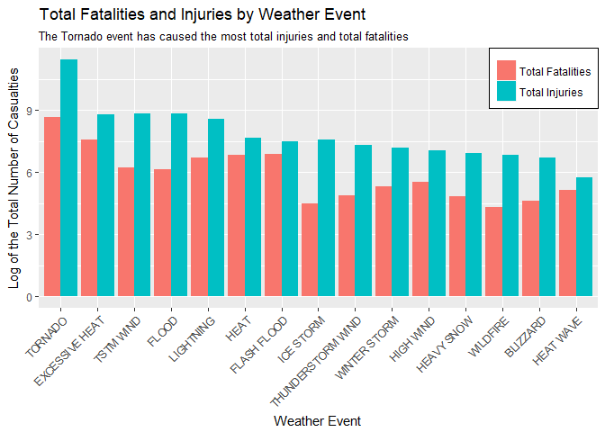

```r
# Plot the most harmful weather events
most_harmful %>% gather(value = casualties,
                        key = type,
                        total_fatalities,
                        total_injuries) %>%
        ggplot(aes(x = reorder(EVTYPE,
                               desc(casualties)),
                   y = log(casualties),
                   fill = type)) +
        geom_bar(stat = "identity",
                 position = "dodge") +
        labs(title = "Total Fatalities and Injuries by Weather Event",
             subtitle = paste("The Tornado event has caused",
                              "the most total injuries and total fatalities"),
             x = "Weather Event",
             y = "Log of the Total Number of Casualties") +
        theme(axis.text.x = element_text(angle = 45,
                                         vjust = 1,
                                         hjust=1),
              legend.title = element_blank(),
              legend.justification = c(1, 1),
              legend.position = c(1, 1),
              legend.background = element_rect(color = 1)) +
        scale_fill_discrete(breaks = c("total_fatalities",
                                       "total_injuries"),
                            labels = c("Total Fatalities",
                                       "Total Injuries"))
```

In order to more easily compare all weather events, we have performed a log transformation on the dependent variable (the total number of casualties). We have also separated casualties into fatalities (in red) and injuries (in blue) for comparison. It is easy to see that tornadoes have caused more deaths and injuries then any other weather event.

Next we will look at the weather events that have caused the most property damage.

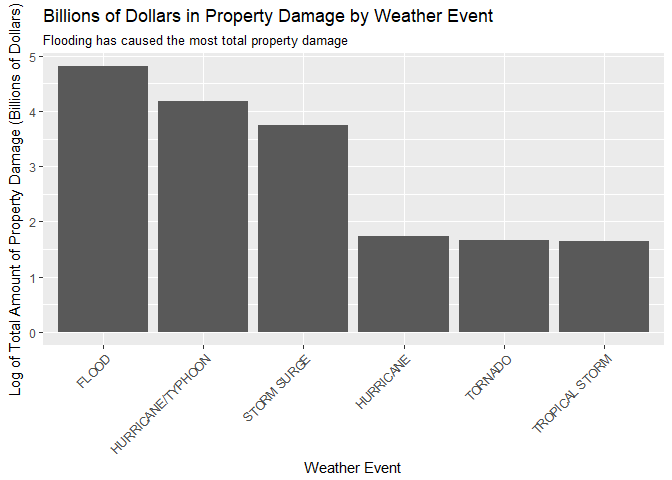

```r
# Plot the most property damaging events
storm_data3 %>% head() %>%
        ggplot(aes(x = reorder(EVTYPE,
                               desc(prop_dmg)),
                   y = log(prop_dmg))) +
        geom_bar(stat = "identity") +
        theme(axis.text.x = element_text(angle = 45,
                                         vjust = 1,
                                         hjust=1)) +
        labs(title = "Billions of Dollars in Property Damage by Weather Event",
             subtitle = "Flooding has caused the most total property damage",
             x = "Weather Event",
             y = "Log of Total Amount of Property Damage (Billions of Dollars)")
```

We have similarly performed a log transformation of the dependent variable for the sake of comparison, and we find that floods have casued the most amount of property damage.

Finally we will take a look at the events which have caused the most damage to crops.

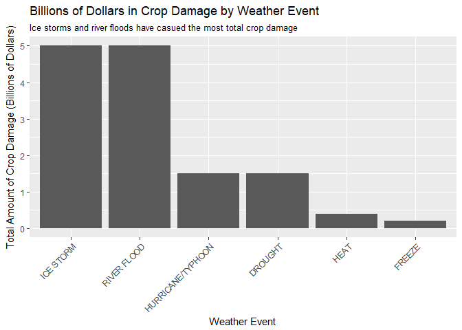

```r
# Plot the most crop damaging events
storm_data4 %>% ggplot(aes(x = reorder(EVTYPE,
                                       desc(crop_dmg)),
                           y = crop_dmg)) +
        geom_bar(stat = "identity") +
        theme(axis.text.x = element_text(angle = 45,
                                         vjust = 1,
                                         hjust=1)) +
        labs(title = "Billions of Dollars in Crop Damage by Weather Event",
             subtitle = paste("Ice storms and river floods have",
                              "casued the most total crop damage"),
             x = "Weather Event",
             y = "Total Amount of Crop Damage (Billions of Dollars)")
```

Since these events have caused a similar amount of crop damage (in billions of dollars), we don’t need to perform a log transformation. We can see that ice storms and river floods have both caused 5 billion dollars in total crop damage.